# R Notebook

```r
library("pasilla")
pasCts <- system.file("extdata", "pasilla_gene_counts.tsv",
package="pasilla", mustWork=TRUE)
pasAnno <- system.file("extdata", "pasilla_sample_annotation.csv",
package="pasilla", mustWork=TRUE)
countData <- as.matrix(read.csv(pasCts,sep="\t",row.names="gene_id"))
colData <- read.csv(pasAnno, row.names=1)
colData <- colData[,c("condition","type")]
head(countData)
```

```
            untreated1 untreated2 untreated3 untreated4 treated1 treated2 treated3
FBgn0000003          0          0          0          0        0        0        1
FBgn0000008         92        161         76         70      140       88       70
FBgn0000014          5          1          0          0        4        0        0
FBgn0000015          0          2          1          2        1        0        0
FBgn0000017       4664       8714       3564       3150     6205     3072     3334
FBgn0000018        583        761        245        310      722      299      308
```

[figure not shown]

```r
#Reduce experiment to just the two AS_minus and AS_plus experiments
klCountData_plusminus <- klCountData[,c("AS1_minus","AS2_minus", "AS1_plus","AS2_plus")]
klMetaData_plusminus <- klMetaData[c("AS1_minus","AS2_minus","AS1_plus","AS2_plus"), ,drop = FALSE]
dds_plusminus = DESeqDataSetFromMatrix(countData = klCountData_plusminus, colData = klMetaData_plusminus, design = ~condition)
```

```
factor levels were dropped which had no samples
```

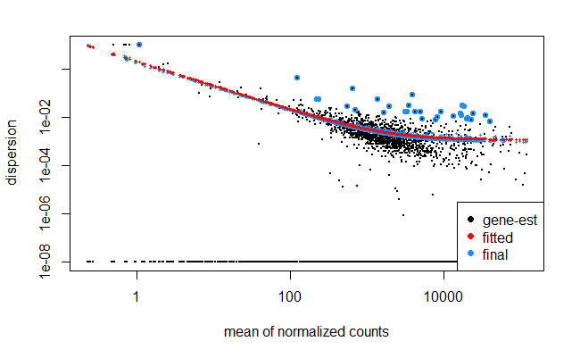

```r
dds_plusminus$condition <- factor(dds_plusminus$condition, levels = c("AS_minus", "AS_plus"))
dds_plusminus_out = DESeq(dds_plusminus)
plotDispEsts(dds_plusminus_out)
```

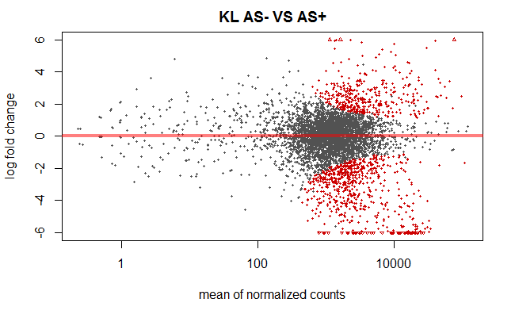

```r
res = results(dds_plusminus_out,  alpha = 10e-100)
resMLE <- results(dds_plusminus_out, addMLE=TRUE,  alpha = 10e-100)
plotMA(res, main = "KL AS- VS AS+", ylim = c(-6,6))
par(mfrow=c(1,2))
```

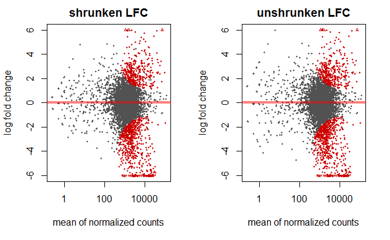

```r
plotMA(res, main = "shrunken LFC", ylim = c(-6,6))
plotMA(resMLE, MLE=TRUE, main="unshrunken LFC", ylim=c(-6,6))
```

```r
#Sort results and write as a .csv file
resOrdered <- res[order(res$padj),]
write.csv(as.data.frame(resOrdered),
          file="C:/Users/Ben/Documents/GitHub/expression_broad_data/expression_data/kl_PKA_as_20160824/DESEQ_KLac_ASmin_ASplus.csv")
```

```r
#SC analysis
scCountData <- CountData[,c("SC_WT_minus","SC_WT_plus","SC_AS_plus")]
scMetaData <- metaData[c("SC_AS_plus","SC_WT_minus","SC_WT_plus"),]
```

dds[ rowSums(counts(dds)) > 1, ]

library(reshape2) library(ggplot2) d <- melt(diamonds[,-c(2:4)]) ggplot(d,aes(x = value)) + facet_wrap(~variable,scales = “free_x”) + geom_histogram()

ggplot(vegLengths, aes(lengthg)) + geom_histogram(alpha = 0.5, aes(y = ..density..), position = ‘identity’)

Multi factor design: design(ddsMF) <- formula(~ type + condition) ddsMF <- DESeq(ddsMF)

Set blind = FALSE

?? What’s the difference between rlog and rlogTransformation

Example suggests just doing the command DESEQ

Commands from Kieran: dds_all = DESeqDataSetFromMatrix(countData = raw_counts, colData = meta, ~1) rld_all <- rlogTransformation(dds_all) rlogm_all <- assay(rld_all_filtered)

meanSdPlot(rlogm) deseq.R code,

Strange that the ratio of medians normalized data doesn’t really seem to have a normalized sum: > apply(klCountData_psuedo,2,sum) AS1_plus AS2_plus WT_minus WT_plus 13836185 15081192 18936631 13403258 > apply(klCountData_norm,2,sum) AS1_plus AS2_plus WT_minus WT_plus 14825647 14864233 17170150 13906631

Removing NA instead of adding a pseudocount: > apply(klCountData,2,sum) AS1_plus AS2_plus WT_minus WT_plus 13833701 15078708 18934147 13400774 > apply(klCountData_norm,2,sum) AS1_plus AS2_plus WT_minus WT_plus 14820140 14861583 17166059 13902784

I wonder why they used that?

```r
source("https://bioconductor.org/biocLite.R")
```

```
Bioconductor version 3.4 (BiocInstaller 1.24.0), ?biocLite for help
```

```r
biocLite("DESeq2")
```

```
BioC_mirror: https://bioconductor.org
Using Bioconductor 3.4 (BiocInstaller 1.24.0), R 3.3.2 (2016-10-31).
Installing package(s) ‘DESeq2’
```

```
installation path not writeable, unable to update packages: survival
```

Maybe I need to add type? (single read or paired end?)